# Trabajo N°1

Integrantes: Tomás Baigorria e Iván Robles Urquiza

Agosto 2023

# ETL y Presentación de los datos

## Importación de librerías.

```r
library(tidyverse)
library(lubridate)
library(ggplot2)
library(sf)
library(scales)
library(paletteer)
library(kableExtra)
```

## Importación y preparación del dataset primario.

- Importación de archivos:
  - Archivo principal con datos salariales por departamento
  - Códigos de departamentos junto a su nombre
  - Codificación CLAE junto al nombre del rubro correspondiente
  - Datos georreferenciados por departamento
- Luego incorporamos los datos mencionados al data frame principal (dfmain) usando la función *left_join()*

```r
cod_deptos <- read_csv("./Data/diccionario_cod_depto.csv") %>%
            select(codigo_departamento_indec, nombre_departamento_indec)

cod_clae <- read_csv("./Data/diccionario_clae2.csv") %>%
            select(clae2, letra_desc)

datos_geo <- read_sf("./Data/departamentos_arg.geojson") %>%
             select(codigo_departamento_indec, geometry) %>%
             mutate(codigo_departamento_indec = as.numeric(codigo_departamento_indec)) #Usamos el as.numeric() sobre el código de dapartamento para evitar la aparición de NAs por diferencias entre strings.

dfmain <- read_csv("./Data/w_mean_depto_tot_emp_clae2.csv") %>%
        left_join(cod_deptos, by="codigo_departamento_indec") %>%
        left_join(cod_clae, by="clae2") %>%
        left_join(datos_geo, by = "codigo_departamento_indec") %>%
        select(fecha, codigo_departamento_indec,nombre_departamento_indec, clae2, letra_desc, everything())
```

- Por último, visualizamos algunos registros del dataset

```r
kable_styling(kbl(sample_n(dfmain, size = 10)), bootstrap_options = c("striped", "hover"))
```

| fecha | codigo_departamento_indec | nombre_departamento_indec | clae2 | letra_desc | id_provincia_indec | w_mean | geometry |
| --- | --- | --- | --- | --- | --- | --- | --- |
| 2017-11-01 | 82007 | Belgrano | 14 | INDUSTRIA MANUFACTURERA | 82 | 12844 | MULTIPOLYGON (((-62.01345 -… |
| 2022-10-01 | 62035 | El Cuy | 26 | INDUSTRIA MANUFACTURERA | 62 | -99 | MULTIPOLYGON (((-67.28932 -… |
| 2018-07-01 | 6410 | Ituzaingó | 29 | INDUSTRIA MANUFACTURERA | 6 | 54685 | MULTIPOLYGON (((-58.71316 -… |
| 2022-01-01 | 6833 | Tres Arroyos | 29 | INDUSTRIA MANUFACTURERA | 6 | 134144 | MULTIPOLYGON (((-60.68533 -… |
| 2017-05-01 | 6847 | Tres Lomas | 64 | INTERMEDIACIÓN FINANCIERA Y SERVICIOS DE SEGUROS | 6 | 55571 | MULTIPOLYGON (((-62.60783 -… |
| 2022-10-01 | 14014 | Capital | 90 | SERVICIOS ARTÍSTICOS, CULTURALES, DEPORTIVOS Y DE ESPARCIMIENTO | 14 | 44021 | MULTIPOLYGON (((-64.0587 -3… |
| 2018-01-01 | 38007 | Cochinoca | 20 | INDUSTRIA MANUFACTURERA | 38 | 16807 | MULTIPOLYGON (((-65.81453 -… |
| 2015-01-01 | 22084 | Libertador General San Martín | 11 | INDUSTRIA MANUFACTURERA | 22 | 11120 | MULTIPOLYGON (((-60.09242 -… |
| 2017-03-01 | 86056 | Copo | 81 | ACTIVIDADES ADMINISTRATIVAS Y SERVICIOS DE APOYO | 86 | 8904 | MULTIPOLYGON (((-63.42364 -… |
| 2014-10-01 | 6882 | Zárate | 55 | SERVICIOS DE ALOJAMIENTO Y SERVICIOS DE COMIDA | 6 | 8676 | MULTIPOLYGON (((-59.22513 -… |

## Exploración de datos: presencia de missing values y de valores inválidos en el dataset.

- Primero consultamos la cantidad de registros presentes en el dataset

```
## Cantidad de registros:  3439322
```

- Analizamos la presencia de NAs en los diferentes campos

|  | x |
| --- | --- |
| fecha | 0 |
| codigo_departamento_indec | 9408 |
| nombre_departamento_indec | 9408 |
| clae2 | 0 |
| letra_desc | 0 |
| id_provincia_indec | 9408 |
| w_mean | 0 |
| geometry | 0 |

- Procedemos a borrar dichos registros por no ser significativos usando *na.omit()*

```r
dfmain <- na.omit(dfmain)
```

- Observamos la presencia de valores inválidos o absurdos en algunos departamentos (-99)

| nombre_departamento_indec | w_mean |
| --- | --- |
| Adolfo Alsina | -99 |
| Adolfo Alsina | -99 |
| Adolfo Alsina | -99 |
| Adolfo Alsina | -99 |
| Adolfo Alsina | -99 |

- Eliminamos los valores negativos

```r
dfmain <- dfmain %>% filter(w_mean > 0)
```

# 1. La distribución salarial por departamento, expresados en un mapa coroplético

## Preparación de datos para el *Gráfico 1*

- Chequeamos datatype de los elementos de la columna

```
## Tipo de dato:  Date
```

- Detectamos el rango de las fechas del dataset

```
## [1] "2014-01-01" "2023-04-01"
```

- Acotamos la muestra a los registros del último año.
- Calculamos el promedio de los últimos 12 registros a fines de obtener una medida del salario promedio por departamento que no se vea sesgada por saltos discretos que pudieran existir en el último período obrante (04/2023).

```r
subdf_depto <- dfmain %>%
                  filter(fecha > (max(fecha) - 365)) %>%
                  group_by(codigo_departamento_indec, nombre_departamento_indec, geometry) %>%
                  summarise(w_mean_lasty = round(mean(w_mean)))

kable_styling(kbl(head(subdf_depto)), bootstrap_options = c("striped", "hover"))
```

| codigo_departamento_indec | nombre_departamento_indec | geometry | w_mean_lasty |
| --- | --- | --- | --- |
| 2000 | CABA | MULTIPOLYGON EMPTY | 386068 |
| 6007 | Adolfo Alsina | MULTIPOLYGON (((-63.28663 -… | 248614 |
| 6014 | Adolfo Gonzales Chaves | MULTIPOLYGON (((-60.45468 -… | 189554 |
| 6021 | Alberti | MULTIPOLYGON (((-60.46106 -… | 216448 |
| 6028 | Almirante Brown | MULTIPOLYGON (((-58.31264 -… | 263790 |
| 6035 | Avellaneda | MULTIPOLYGON (((-58.33444 -… | 274449 |

### *Gráfico 1*

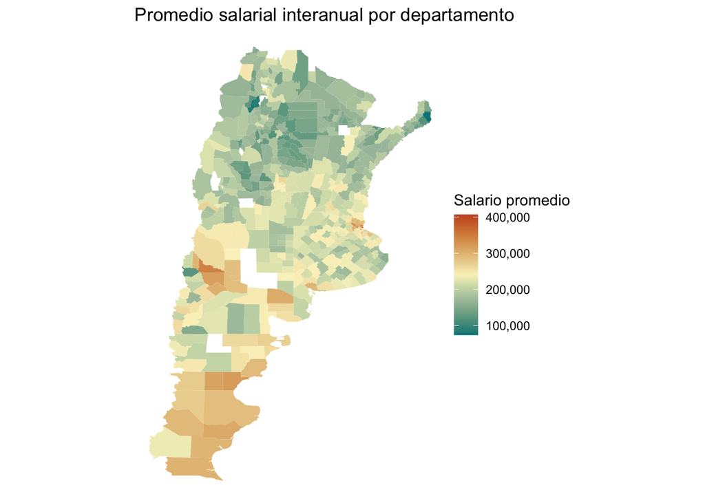

> La representación geográfica de los datos expone cierta tendencia por regiones que permite proponer diferentes conclusiones:
> 1. La región patagónica presenta un salario promedio alto; con algunas regiones aisladas como excepción, que presentan salarios medios y bajos.
> 2. El NOA es la región donde se concentran los menores salarios, no presentándose casos de regiones con altos salarios.
> 3. En la Provincia de Buenos Aires, la región del AMBA concentra los mayores salarios, mientras que en el interior de la provincia rondan entre medios y bajos.

> Nótese que ciertas regiones carecen de representación gráfica según la escala (en blanco). Esto se debe a que algunas localidades específicas no contaban con información salarial o geográfica. El procedimiento para eliminar estos registros vacíos se llevó a cabo en Exploración de datos: presencia de missing values y de valores inválidos en el dataset..

# 2. Los 5 sectores de actividad con salarios más bajos, expresados en un gráfico de barras

## Preparación de datos para el *Gráfico 2*

- Al igual que en el caso anterior, acotamos los datos a los últimos 12 registros
- Ordenamos los promedios salariales de forma ascendente y nos quedamos con los primeros 5 registros.
- Por último, usando fct_inorder() (del paquete forcats) ordenamos los factores de forma que las columnas aparezcan en el gráfico en forma ascendente.

```r
subdf_act_salarios <- dfmain %>%
                  filter(fecha > (max(fecha) - 365)) %>%
                  group_by(letra_desc) %>%
                  summarise(w_mean_lasty = round(mean(w_mean))) %>%
                  arrange(w_mean_lasty) %>%
                  head(n=5) %>%
                  mutate(letra_desc = fct_inorder(letra_desc))
```

## *Gráfico 2*

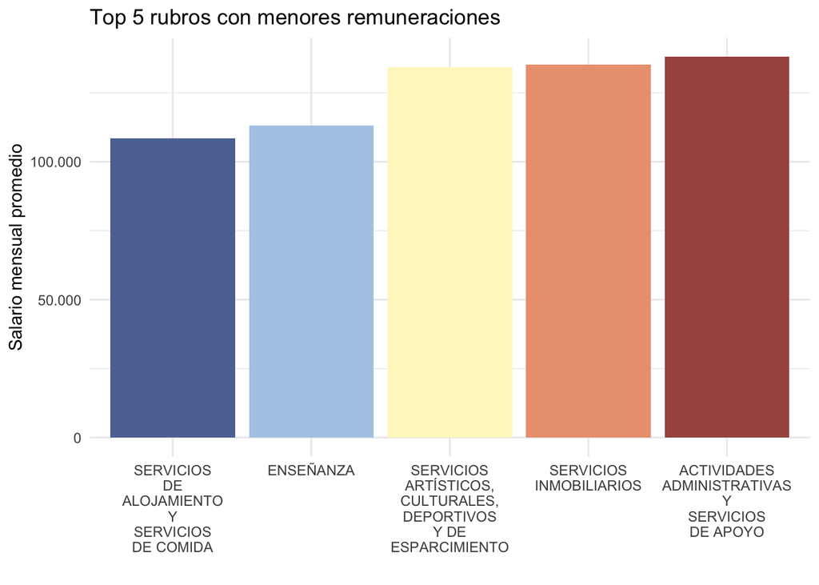

> En esta representación, se exponen aquellos grandes sectores con los salarios más bajos del mercado. Siendo los **Servicios de alojamiento y servicios de comida** el de menor remuneración neta.

# 3. Evolución de los salarios nominales de 4 sectores para el período 2014 - 2023, en un gráfico de líneas.

## Preparación de datos para el *Gráfico 3*

- Chequeamos los diferentes sectores

| x |
| --- |
| AGRICULTURA, GANADERÍA, CAZA, SILVICULTURA Y PESCA |
| EXPLOTACION DE MINAS Y CANTERAS |
| INDUSTRIA MANUFACTURERA |
| SUMINISTRO DE ELECTRICIDAD, GAS, VAPOR Y AIRE ACONDICIONADO |
| SUMINISTRO DE AGUA; CLOACAS; GESTIÓN DE RESIDUOS Y RECUPERACIÓN DE MATERIALES Y SANEAMIENTO PUBLICO |
| CONSTRUCCIÓN |
| COMERCIO AL POR MAYOR Y AL POR MENOR; REPARACIÓN DE VEHÍCULOS AUTOMOTORES Y MOTOCICLETAS |
| SERVICIO DE TRANSPORTE Y ALMACENAMIENTO |
| SERVICIOS DE ALOJAMIENTO Y SERVICIOS DE COMIDA |
| INFORMACIÓN Y COMUNICACIONES |
| INTERMEDIACIÓN FINANCIERA Y SERVICIOS DE SEGUROS |
| SERVICIOS INMOBILIARIOS |
| SERVICIOS PROFESIONALES, CIENTÍFICOS Y TÉCNICOS |
| ACTIVIDADES ADMINISTRATIVAS Y SERVICIOS DE APOYO |
| ENSEÑANZA |
| SALUD HUMANA Y SERVICIOS SOCIALES |
| SERVICIOS ARTÍSTICOS, CULTURALES, DEPORTIVOS Y DE ESPARCIMIENTO |
| SERVICIOS DE ASOCIACIONES Y SERVICIOS PERSONALES |
| OTROS |

- Nos quedamos con 4 de ellos:
  1. Explotación de minas y canteras
  2. Servicio de transporte y almacenamiento
  3. Construcción
  4. Enseñanza

**Agrupamos por fecha y rubro y utilizamos *summarise()* para obtener el promedio de las observaciones de todos los departamentos**

```r
subdf_act_serie <- dfmain %>%
                select(fecha, letra_desc, w_mean) %>%
                filter(letra_desc == "EXPLOTACION DE MINAS Y CANTERAS"
                       | letra_desc == "SERVICIO DE TRANSPORTE Y ALMACENAMIENTO"
                       | letra_desc == "CONSTRUCCIÓN"
                       | letra_desc == "ENSEÑANZA") %>%
                group_by(fecha, letra_desc) %>%
                summarise(w_mean = mean(w_mean)) %>%
                mutate(letra_desc = fct_relevel(letra_desc, c("EXPLOTACION DE MINAS Y CANTERAS", "SERVICIO DE TRANSPORTE Y ALMACENAMIENTO", "CONSTRUCCIÓN", "ENSEÑANZA")))
```

## *Gráfico 3*

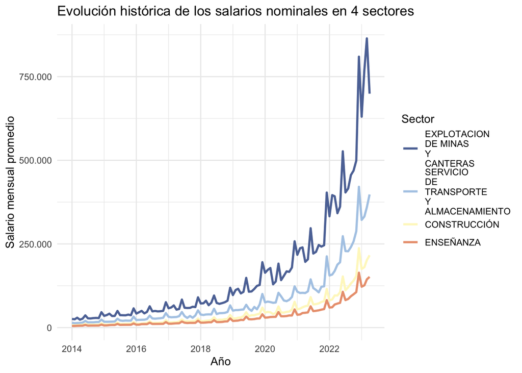

> El gráfico permite una comparación nominal entre los seectores seleccionados. La tendencia es creciente para todos ellos aunque la interpretación que de aquí pueda partir deberá contemplar el sesgo de la nominalidad, en consideración del régimen de alta inflación vigente en la economía. Concluímos:
> 1. El sector de **Explotación de minas y canteras** promedia los mayores salarios y **Enseñanza** los menores.
> 2. La tendencia alcista es generalizada, mas no implica en sí misma un incremento del salario real. La asociamos *prima facie* al fenómeno inflacionario.
> 3. En términos de la nominalidad, los salarios suben de de forma exponencial a lo largo de la serie.